# Logistic regression and prediction

Gerko Vink

The aim of this document is to highlight some workflows for generating confidence intervals and prediction intervals for individual values. I outline parametric and bootstrap approaches and demonstrate that these approaches are equivalent; at least for a sufficient number of bootstraps.

# Load required packages

```r
library(tidyverse)
library(magrittr)
```

```r
library(purrr)
library(ggplot2)
library(GGally)
library(ciTools)
library(caret)
library(marginaleffects)
library(insight)
set.seed(123)
```

# Grab the `titanic` data

We start with the titanic data set, that can be grabbed from my website.

```r
con <- url("https://www.gerkovink.com/erasmus/Day%202/Part%20D/titanic.csv")
titanic <- read_csv(con)
```

# Some data editing

I make sure that the categorical variables are correctly coded as factors, and I add a row indicator. We need this indicator later on, when we are using the bootstrap. Otherwise we cannot relate the bootstrapped estimates to the orginal cases.

```r
titanic %<>%
  mutate(Pclass = factor(Pclass, labels = c("1st class", "2nd class", "3rd class")),
         Survived = factor(Survived, labels = c("No", "Yes")),
         row = 1:887)
```

# Draw 10000 bootstrapped sets

I draw 10,000 bootstrapped samples out of the `titanic` set, where each sample is of the same length ($N=887$) and every row is randomly sampled with replacement.

```r
boot <- replicate(n = 10000,
                  expr = titanic[sample(nrow(titanic),
                                        replace = TRUE), ],
                  simplify = FALSE)
```

The `simplify = FALSE` statement is to keep the list structure in the object `boot`. I can then, later on, use this list structure to run my functional programming over.

# Fit logistic model on true data set

This is the baseline model on the observed (not bootstrapped) data

```r
fit <- titanic %$%
  glm(Survived ~ Pclass + Sex + Age, family = binomial(link = "logit"))
```

## Coefficients

Model `fit` has the following coefficients:

```r
fit %>% coef()
```

```
##     (Intercept) Pclass2nd class Pclass3rd class         Sexmale             Age
##      3.63492051     -1.19911501     -2.45544258     -2.58872040     -0.03427498
```

## Parameter CI’s

Model `fit` has the following corresponding coefficients confidence intervals (95%):

```r
fit %>% confint
```

```
##                      2.5 %     97.5 %
## (Intercept)      2.9277366  4.3814230
## Pclass2nd class -1.7182398 -0.6916866
## Pclass3rd class -2.9628768 -1.9689833
## Sexmale         -2.9630319 -2.2291259
## Age             -0.0485558 -0.0204524
```

## Standard errors

The coefficient standard errors are:

```r
fit %>% summary %>% .$coefficients
```

```
##                    Estimate  Std. Error    z value     Pr(>|z|)
## (Intercept)      3.63492051 0.370455409   9.812032 9.993507e-23
## Pclass2nd class -1.19911501 0.261581654  -4.584094 4.559581e-06
## Pclass3rd class -2.45544258 0.253223337  -9.696747 3.112650e-22
## Sexmale         -2.58872040 0.187006290 -13.842959 1.403098e-43
## Age             -0.03427498 0.007160088  -4.786950 1.693352e-06
```

# Fit logistic models on all bootstrap sets

Now we repeat the model fit on all bootstrapped sets. I use `purrr::map()` to fit the same generalized linear model on each listed dimension in `boot`, where every listed dimension contains a single bootstrapped sample from `titanic`.

```r
bootfit <- boot %>%
  map(~.x %$%
        glm(Survived ~ Pclass + Sex + Age,
            family = binomial(link = "logit")))
```

## Bootstrapped Coefficients

The average bootstrapped coefficient are:

```r
bootcoef <- bootfit %>%
  map(~.x %>% coef()) %>%
  do.call("rbind", .) %>%
  as_tibble()

bootcoef %>% colMeans()
```

```
##     (Intercept) Pclass2nd class Pclass3rd class         Sexmale             Age
##      3.67191475     -1.21292073     -2.47815598     -2.60922718     -0.03468966
```

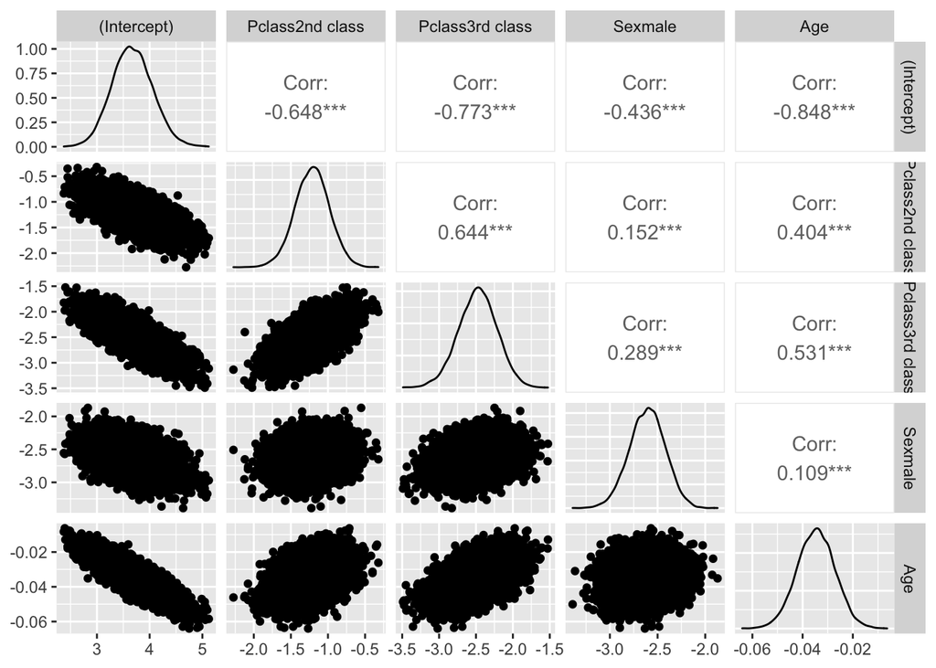

```r
ggpairs(bootcoef)
```

## Bootstrapped CI’s

The average bootstrapped percentile-based confidence intervals are:

```r
bootcoef %>%
  sapply(., function(x) quantile(x, c(.025, .975))) %>% t()
```

```
##                        2.5%       97.5%
## (Intercept)      2.94290273  4.44920374
## Pclass2nd class -1.67534764 -0.76200272
## Pclass3rd class -3.00467538 -1.97563380
## Sexmale         -2.98366515 -2.25156284
## Age             -0.04969089 -0.02009536
```

## Bootstrapped SE’s

The correponding bootstrapped standard errors across the bootstrapped parameters are :

```r
bootcoef %>%
  sapply(., sd)
```

```
##     (Intercept) Pclass2nd class Pclass3rd class         Sexmale             Age
##      0.38600327      0.23215774      0.26135932      0.18732573      0.00755088
```

# Comparisons

I now compare the original parametrically obtained estimates to the estimates obtained via the bootstrap.

## Coefficients

```r
data.frame(original = fit$coefficients,
           bootstrap = bootcoef %>% colMeans())
```

```
##                    original   bootstrap
## (Intercept)      3.63492051  3.67191475
## Pclass2nd class -1.19911501 -1.21292073
## Pclass3rd class -2.45544258 -2.47815598
## Sexmale         -2.58872040 -2.60922718
## Age             -0.03427498 -0.03468966
```

## Confidence intervals

```r
list(original = fit %>% confint(),
     bootstrap = bootcoef %>%
       sapply(., function(x) quantile(x, c(.025, .975))) %>% t())
```

```
## $original
##                      2.5 %     97.5 %
## (Intercept)      2.9277366  4.3814230
## Pclass2nd class -1.7182398 -0.6916866
## Pclass3rd class -2.9628768 -1.9689833
## Sexmale         -2.9630319 -2.2291259
## Age             -0.0485558 -0.0204524
##
## $bootstrap
##                        2.5%       97.5%
## (Intercept)      2.94290273  4.44920374
## Pclass2nd class -1.67534764 -0.76200272
## Pclass3rd class -3.00467538 -1.97563380
## Sexmale         -2.98366515 -2.25156284
## Age             -0.04969089 -0.02009536
```

## Standard Errors

```r
data.frame(original = fit %>% summary %>% .$coefficients %>% .[, 2],
           bootstrap = bootcoef %>%
  sapply(., sd))
```

```
##                    original  bootstrap
## (Intercept)     0.370455409 0.38600327
## Pclass2nd class 0.261581654 0.23215774
## Pclass3rd class 0.253223337 0.26135932
## Sexmale         0.187006290 0.18732573
## Age             0.007160088 0.00755088
```

We can see that the bootstrap is a valid approximation to the parameters and statistics obtained on the original data set.

# Individual intervals

Now let’s calculate individual intervals via the bootstrap

## Bootstrap individual interval

The following codeblock calculates for every case in the `titanic` data the predicted value, the standard error of the predicted value and the corresponding row number. I combine these into a `tibble` with 3 columns: one for the rows, one for the predictions and one for the corresponding standard error.

```r
# create matrix with size bootstrap \times cases
pred.matrix <- bootfit %>%
  map(~.x %>% predict()) %>%
  do.call("rbind", .)

se.matrix <- bootfit %>%
  map(~.x %>% predict(se = TRUE) %>% .$se.fit) %>%
  do.call("rbind", .)

rows.matrix <- boot %>%
  map(~.x %>% .$row)  %>%
  do.call("rbind", .)

# row predictions
pred.data <- data.frame(rows = c(rows.matrix),
                        pred = c(pred.matrix),
                        se = c(se.matrix)) %>%
  as_tibble()
```

Because the rows differ across the bootstrapped sets, I calculate the individual predictions and intervals over the corresponding row identifier. This means that on average, each row will be bootstrapped 10,000 times - but realized bootstrapped lengths may differ over the row numbers.

```r
# calculate centroids and quantiles
pred <- pred.data %>% group_by(rows) %>%
  summarize(est = mean(pred),
            se.fit = mean(se),
            lwr = est - 1.96 * se.fit, #parametric SE
            upr = est + 1.96 * se.fit, #parametric SE
            lwr.q = quantile(pred, .025),
            upr.q = quantile(pred, .975))

# convert to prob
pred %<>% mutate(prob = plogis(est),
                 plwr = plogis(lwr),
                 pupr = plogis(upr),
                 plwr.q = plogis(lwr.q),
                 pupr.q = plogis(upr.q))

# head of predictions calculated
pred
```

```
## # A tibble: 887 × 12
##     rows    est se.fit      lwr    upr    lwr.q  upr.q   prob   plwr   pupr
##    <int>  <dbl>  <dbl>    <dbl>  <dbl>    <dbl>  <dbl>  <dbl>  <dbl>  <dbl>
##  1     1 -2.18   0.163 -2.50    -1.86  -2.56    -1.84  0.102  0.0761 0.135
##  2     2  2.36   0.227  1.91     2.80   1.96     2.78  0.914  0.871  0.943
##  3     3  0.303  0.156 -0.00254  0.608 -0.00494  0.614 0.575  0.499  0.648
##  4     4  2.46   0.230  2.01     2.91   2.06     2.90  0.921  0.882  0.949
##  5     5 -2.63   0.187 -3.00    -2.27  -3.07    -2.25  0.0669 0.0474 0.0938
##  6     6 -2.35   0.166 -2.68    -2.03  -2.74    -2.01  0.0869 0.0643 0.116
##  7     7 -0.823  0.200 -1.22    -0.431 -1.21    -0.455 0.305  0.229  0.394
##  8     8 -1.49   0.219 -1.92    -1.06  -1.97    -1.04  0.184  0.128  0.257
##  9     9  0.267  0.157 -0.0406   0.574 -0.0468   0.586 0.566  0.490  0.640
## 10    10  1.98   0.244  1.50     2.46   1.56     2.42  0.878  0.818  0.921
## # … with 877 more rows, and 2 more variables: plwr.q <dbl>, pupr.q <dbl>
```

## Compare predictions

If we compare the predicted values obtained on the original data to the predicted values obtained via the bootstrap in a Q-Q plot, we find that their distribution is very close. Increasing the number of bootstraps will bring them closer.

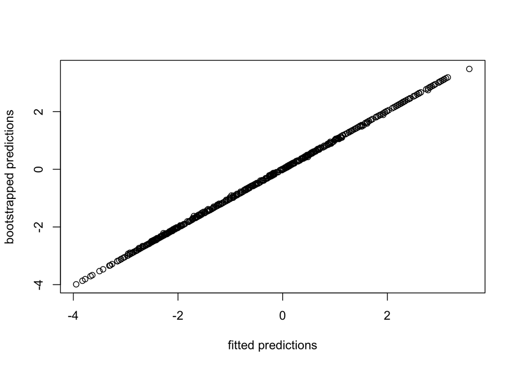

```r
plot(x = fit %>% predict,
     y = pred$est,
     xlab = "fitted predictions",
     ylab = "bootstrapped predictions")
```

## Compare se’s

The same holds for the estimated standard errors.

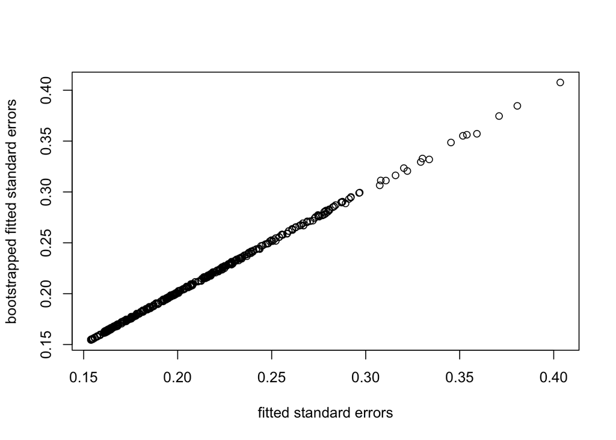

```r
y_se <- fit %>%
  predict(se = TRUE) %>%
  as.data.frame()
plot(x = y_se$se.fit,
     y = pred$se.fit,
     xlab = "fitted standard errors",
     ylab = "bootstrapped fitted standard errors")
```

## Individual interval true model

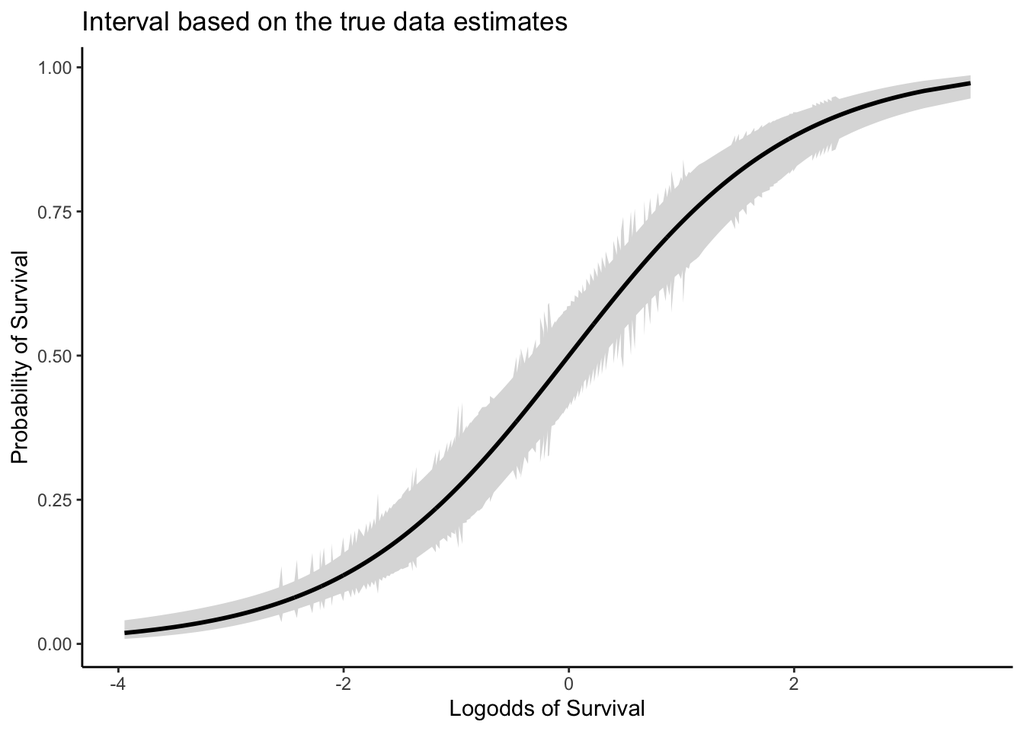

```r
fit %>%
  predict(se = TRUE) %>%
  as.data.frame() %>%
  mutate(prob = plogis(fit),
         lwr = plogis(fit - 1.96 * se.fit),
         upr = plogis(fit + 1.96 * se.fit)) %>%
  ggplot(aes(x = fit, y = prob)) +
  geom_ribbon(aes(ymin = lwr, ymax = upr), alpha = .2) +
  geom_line(lwd = 1) + ylab("Probability of Survival") + xlab("Logodds of Survival") + ggtitle("Interval based on the true data estimates") + theme_classic()
```

## Individual interval bootstrapped se

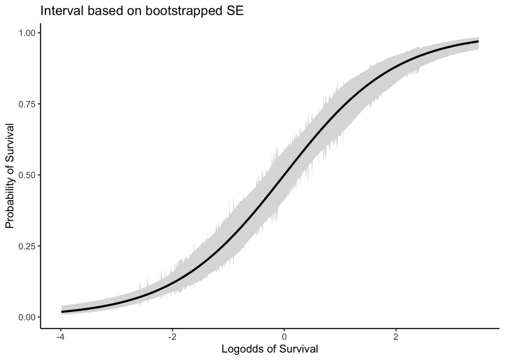

```r
pred %>%
  ggplot(aes(x = est, y = prob)) +
  geom_ribbon(aes(ymin = plwr, ymax = pupr), alpha = .2) +
  geom_line(lwd = 1) + ylab("Probability of Survival") + xlab("Logodds of Survival") + ggtitle("Interval based on bootstrapped SE") + theme_classic()
```

## Individual interval bootstrapped quantile

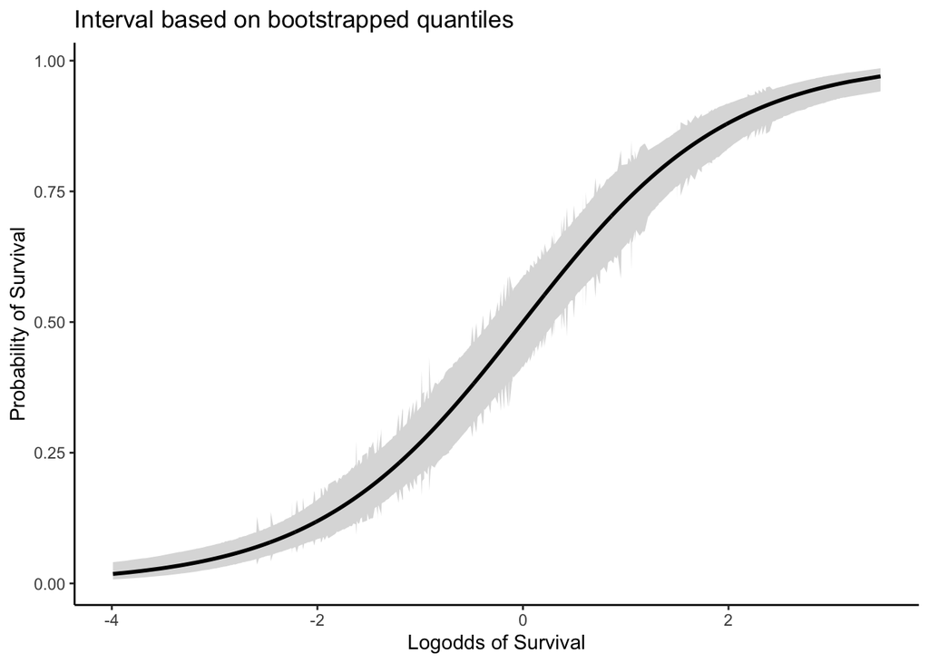

```r
pred %>%
  ggplot(aes(x = est, y = prob)) +
  geom_ribbon(aes(ymin = plwr.q, ymax = pupr.q), alpha = .2) +
  geom_line(lwd = 1) + ylab("Probability of Survival") + xlab("Logodds of Survival") + ggtitle("Interval based on bootstrapped quantiles") + theme_classic()
```

# Confusion Matrices

## Original data predictions (reference = truth)

```r
yhat <- fit %>%
  predict(type = "response")

yhat <- ifelse(yhat > .5, "Yes", "No") %>%  # easy threshold for brevity
  as.factor()

confusionMatrix(yhat, titanic$Survived)
```

```
## Confusion Matrix and Statistics
##
##           Reference
## Prediction  No Yes
##        No  463 100
##        Yes  82 242
##
##                Accuracy : 0.7948
##                  95% CI : (0.7667, 0.8209)
##     No Information Rate : 0.6144
##     P-Value [Acc > NIR] : <2e-16
##
##                   Kappa : 0.5627
##
##  Mcnemar's Test P-Value : 0.2076
##
##             Sensitivity : 0.8495
##             Specificity : 0.7076
##          Pos Pred Value : 0.8224
##          Neg Pred Value : 0.7469
##              Prevalence : 0.6144
##          Detection Rate : 0.5220
##    Detection Prevalence : 0.6347
##       Balanced Accuracy : 0.7786
##
##        'Positive' Class : No
##
```

## Bootstrapped predictions (reference = truth)

```r
predicted <- ifelse(pred$prob > .5, "Yes", "No") %>%
  as.factor()

confusionMatrix(predicted, titanic$Survived)
```

```
## Confusion Matrix and Statistics
##
##           Reference
## Prediction  No Yes
##        No  463  99
##        Yes  82 243
##
##                Accuracy : 0.7959
##                  95% CI : (0.7679, 0.822)
##     No Information Rate : 0.6144
##     P-Value [Acc > NIR] : <2e-16
##
##                   Kappa : 0.5653
##
##  Mcnemar's Test P-Value : 0.2343
##
##             Sensitivity : 0.8495
##             Specificity : 0.7105
##          Pos Pred Value : 0.8238
##          Neg Pred Value : 0.7477
##              Prevalence : 0.6144
##          Detection Rate : 0.5220
##    Detection Prevalence : 0.6336
##       Balanced Accuracy : 0.7800
##
##        'Positive' Class : No
##
```

## Bootstrapped vs original data predictions (reference = bootstrap)

```r
confusionMatrix(yhat, predicted) # bootstrap is reference
```

```
## Confusion Matrix and Statistics
##
##           Reference
## Prediction  No Yes
##        No  562   1
##        Yes   0 324
##
##                Accuracy : 0.9989
##                  95% CI : (0.9937, 1)
##     No Information Rate : 0.6336
##     P-Value [Acc > NIR] : <2e-16
##
##                   Kappa : 0.9976
##
##  Mcnemar's Test P-Value : 1
##
##             Sensitivity : 1.0000
##             Specificity : 0.9969
##          Pos Pred Value : 0.9982
##          Neg Pred Value : 1.0000
##              Prevalence : 0.6336
##          Detection Rate : 0.6336
##    Detection Prevalence : 0.6347
##       Balanced Accuracy : 0.9985
##
##        'Positive' Class : No
##
```

# Checks

## Check the individual`se.fit`

Let’s identify if we can replicate the `se.fit` calculation. First, lets manually calculate the `se.fit` that is produced by `predict()`.

```r
# For the whole data
pred <- predict(fit, se = TRUE)
X <- model.matrix(fit) # Design matrix
sefun <- function(x) sqrt(t(x) %*% vcov(fit) %*% x)
SE.manual <- apply(X, 1, sefun)
all.equal(pred$se.fit,SE.manual) # SAME
```

```
## [1] TRUE
```

That works.

## Is this the same as the interval stated in e.g. the book by Agresti?

[Agresti](https://www.wiley.com/en-gb/Categorical+Data+Analysis%2C+3rd+Edition-p-9780470463635) (pp. 170) states:

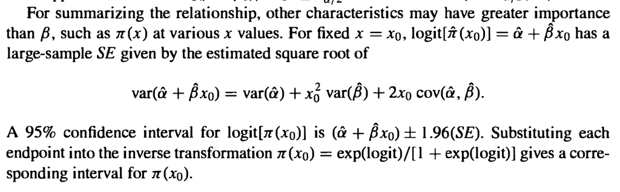

Let’s find out:

```r
#Let's take a simple model for reasons of simplicity.
fit1 <- titanic %$%
  glm(Survived ~ Age, family = binomial(link = "logit"))
vcov(fit1)
```

```
##               (Intercept)           Age
## (Intercept)  0.0254382353 -7.111544e-04
## Age         -0.0007111544  2.447639e-05
```

```r
# using predict()
predict(fit1, newdata = data.frame(Age = 22), se.fit = TRUE)
```

```
## $fit
##          1
## -0.4022246
##
## $se.fit
## [1] 0.07742101
##
## $residual.scale
## [1] 1
```

```r
# cf. Agresti pp 170-171
sqrt(0.0254382353 + 22^2 * 2.447639e-05 + 2*22 * -0.0007111544)
```

```
## [1] 0.07742102
```

```r
## THOSE ARE IDENTICAL!
```

YES, both estimates are identical. Agresti yields the same estimated standard error of individual fit as `predict()`.

Some additional checks across packages.

```r
predict(fit, se.fit = TRUE) %>%
  as.data.frame() %>%
  mutate(prob = plogis(fit),
         lwr = plogis(fit - qt(.975, Inf) * se.fit),
         upr = plogis(fit + qt(.975, Inf) * se.fit)) %>% head()
```

```
##          fit    se.fit residual.scale       prob        lwr       upr
## 1 -2.1632921 0.1611160              1 0.10309564 0.07733827 0.1361655
## 2  2.3324712 0.2250222              1 0.91153082 0.86891916 0.9412273
## 3  0.2883284 0.1549047              1 0.57158684 0.49618027 0.6438092
## 4  2.4352961 0.2282301              1 0.91947951 0.87952856 0.9469805
## 5 -2.6088669 0.1848632              1 0.06856994 0.04874441 0.0956482
## 6 -2.3346670 0.1645227              1 0.08829226 0.06555118 0.1179271
```

```r
# from package insight
get_predicted_ci(fit,
                 predictions = get_predicted(fit),
                 ci_type = "prediction") %>%
  head()
```

```
##   CI_low.Predicted  CI_low.SE CI_low.CI_low CI_low.CI_high CI_high.Predicted
## 1             -Inf 0.01489791    0.07733827      0.1361655               Inf
## 2             -Inf 0.01814632    0.86891916      0.9412273               Inf
## 3             -Inf 0.03793233    0.49618027      0.6438092               Inf
## 4             -Inf 0.01689746    0.87952856      0.9469805               Inf
## 5             -Inf 0.01180686    0.04874441      0.0956482               Inf
## 6             -Inf 0.01324354    0.06555118      0.1179271               Inf
##   CI_high.SE CI_high.CI_low CI_high.CI_high
## 1 0.01489791     0.07733827       0.1361655
## 2 0.01814632     0.86891916       0.9412273
## 3 0.03793233     0.49618027       0.6438092
## 4 0.01689746     0.87952856       0.9469805
## 5 0.01180686     0.04874441       0.0956482
## 6 0.01324354     0.06555118       0.1179271
```

## Are prediction intervals wider than confidence intervals

Of course they are. Some proof for a linear model:

```r
fit0 <- lm(hgt ~ age, data = mice::boys)

# confidence interval
predict(fit0, interval = "confidence") %>% head()
```

```
##         fit      lwr      upr
## 3  70.93310 69.67496 72.19124
## 4  70.95288 69.69500 72.21076
## 18 71.07815 69.82194 72.33437
## 23 71.09793 69.84198 72.35389
## 28 71.11112 69.85534 72.36690
## 36 71.15068 69.89543 72.40593
```

```r
# prediction interval
predict(fit0, interval = "prediction") %>% head()
```

```
## Warning in predict.lm(fit0, interval = "prediction"): predictions on current data refer to _future_ responses
```

```
##         fit      lwr      upr
## 3  70.93310 50.69346 91.17274
## 4  70.95288 50.71326 91.19250
## 18 71.07815 50.83863 91.31767
## 23 71.09793 50.85843 91.33744
## 28 71.11112 50.87163 91.35061
## 36 71.15068 50.91122 91.39014
```

Note that the warning states that the predictions refer to future responses. Hence, the larger variance and wider intervals.